# 07-1-LogReg_plasma

2025-02-06

### Code Accompanying *The Machine Learning Handbooks*, Volume I, Chapter 7

#### Book pdf is available on the GitHub repo: https://github.com/kjmazidi/Machine_Learning_3rd_edition

### Introduction

This notebook demonstrates logistic regression example using the plasma data set in package HSAUR.

Packages imported in this notebook:

- HSAUR (A Handbook of Statistical Analyses Using R)
- Data used: plasma from the HSAUR library

```r
if (!require(HSAUR)){
  install.packages("HSAUR")
}
library("HSAUR")
```

### Data exploration

We can read more about the plasma data set by typing “?plasma” at the console, after package HSAUR is loaded. We want to learn to predict ESR>20 or not, based on the levels of the plasma proteins fibrinogen and globulin. ESR stands for erythrocyte sedimentation rate, the rate at which red blood cells settle in blood plasma. Values >20 indicate some possible associations with various health conditions.

```r
str(plasma)
```

```
## 'data.frame':    32 obs. of  3 variables:
##  $ fibrinogen: num  2.52 2.56 2.19 2.18 3.41 2.46 3.22 2.21 3.15 2.6 ...
##  $ globulin  : int  38 31 33 31 37 36 38 37 39 41 ...
##  $ ESR       : Factor w/ 2 levels "ESR < 20","ESR > 20": 1 1 1 1 1 1 1 1 1 1 ...
```

```r
head(plasma)
```

```
##   fibrinogen globulin      ESR
## 1       2.52       38 ESR < 20
## 2       2.56       31 ESR < 20
## 3       2.19       33 ESR < 20
## 4       2.18       31 ESR < 20
## 5       3.41       37 ESR < 20
## 6       2.46       36 ESR < 20
```

### Plot the data

The first pair of plots show us that observations where ESR>20 are rarer. This is indicated by the thinner boxes because we set varwidth=TRUE in the bloxplot call. More importantly, the boxplots show that ESR>20 observations are associated with slightly higher levels of globulin and significantly higher levels of fibronogen.

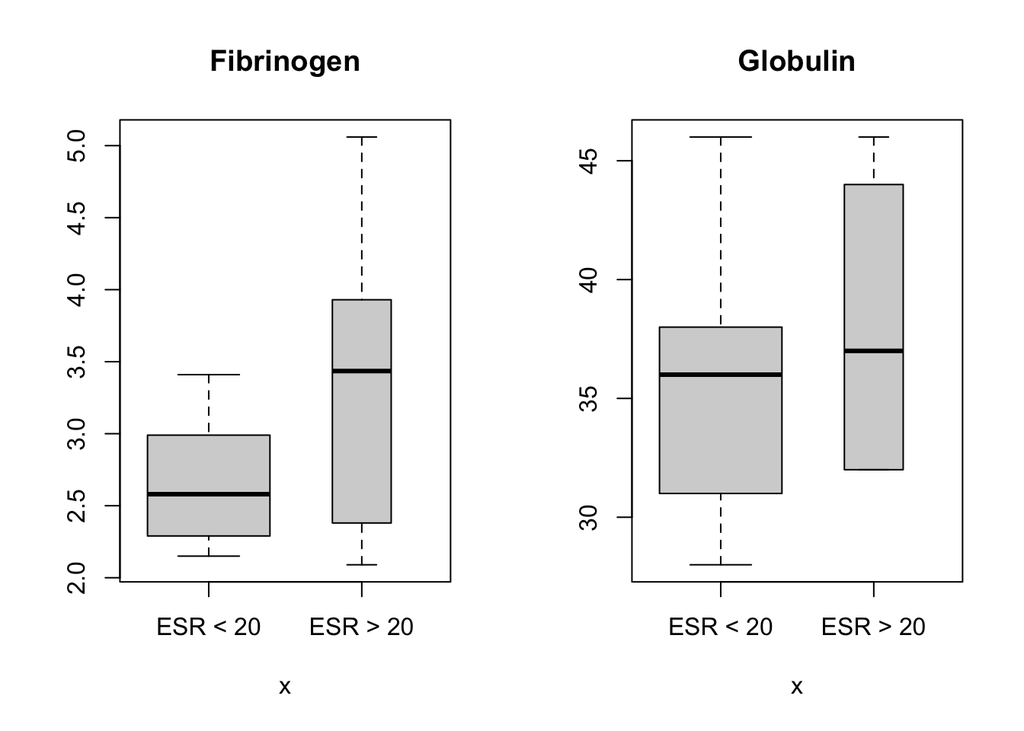

```r
par(mfrow=c(1,2))
plot(plasma$ESR, plasma$fibrinogen, main="Fibrinogen", ylab="", varwidth=TRUE)
plot(plasma$ESR, plasma$globulin, main="Globulin", ylab="", varwidth=TRUE)
```

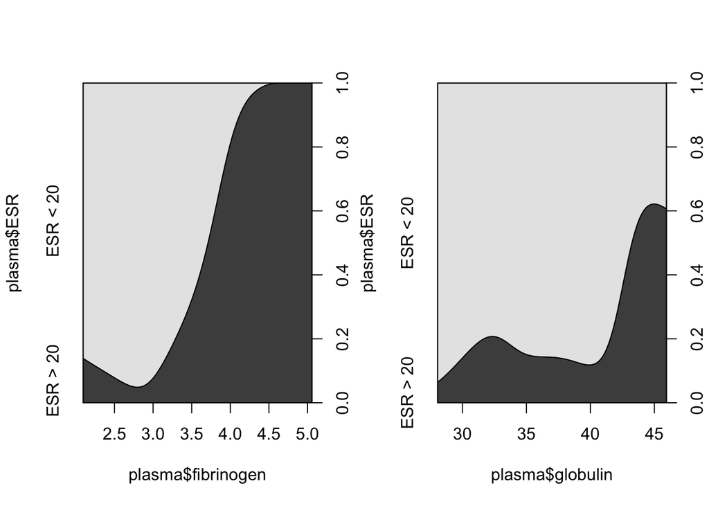

```r
par(mfrow=c(1,2))
cdplot(plasma$ESR~plasma$fibrinogen)
cdplot(plasma$ESR~plasma$globulin)
```

### Train and test sets

Even though our data is small, we will go ahead and divide it into train and test sets.

```r
set.seed(1234)
i <- sample(1:nrow(plasma), 0.75*nrow(plasma), replace=FALSE)
train <- plasma[i,]
test <- plasma[-i,]
```

### Build a logistic regression model

Our first model uses only fibronogen as a predictor. The glm() function is used for logistic regression, with parameter family=binomial

The summary is a little different for logistic regression compared to linear regression: * the residual are deviance residuals - measures of deviance contributed from each observation * the coefficients represent changes in the log odds of y * model metrics

```r
glm1 <- glm(ESR~fibrinogen, data=train, family=binomial)
summary(glm1)
```

```
##
## Call:
## glm(formula = ESR ~ fibrinogen, family = binomial, data = train)
##
## Deviance Residuals:
##     Min       1Q   Median       3Q      Max
## -0.9852  -0.7375  -0.5074  -0.1920   2.2554
##
## Coefficients:
##             Estimate Std. Error z value Pr(>|z|)
## (Intercept)  -5.6141     2.6591  -2.111   0.0347 *
## fibrinogen    1.5084     0.8543   1.766   0.0775 .
## ---
## Signif. codes:  0 '***' 0.001 '**' 0.01 '*' 0.05 '.' 0.1 ' ' 1
##
## (Dispersion parameter for binomial family taken to be 1)
##
##     Null deviance: 26.992  on 23  degrees of freedom
## Residual deviance: 22.716  on 22  degrees of freedom
## AIC: 26.716
##
## Number of Fisher Scoring iterations: 4
```

### Evaluate

```r
probs <- predict(glm1,  newdata=test, type="response")
pred <- ifelse(probs> 0.5, 2, 1)
acc <- mean(pred == as.integer(test$ESR))
table(pred, as.integer(test$ESR))
```

```
##
## pred 1
##    1 8
```

### What does it mean?

Let’s explore the meaning of the coefficient.

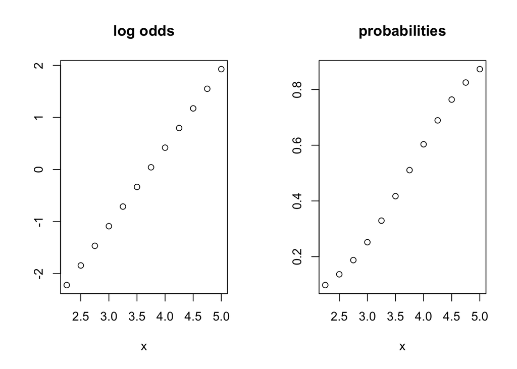

```r
fibro <- glm1$coefficients[2]
intercept <- glm1$coefficients[1]

log_odds <- function(x, fibro, intercept){
  intercept + fibro * x
}

x <- seq(from=2.25, to=5.0, by=0.25)
y <- log_odds(x, fibro, intercept)
par(mfrow=c(1,2))
plot(x,y, main="log odds", ylab="")

prob <- exp(y) / (1 + exp(y))
plot(x, prob, main="probabilities", ylab="")
```

### Build another model

```r
glm2 <- glm(ESR~fibrinogen+globulin, data=train, family=binomial)
summary(glm2)
```

```
##
## Call:
## glm(formula = ESR ~ fibrinogen + globulin, family = binomial,
##     data = train)
##
## Deviance Residuals:
##      Min        1Q    Median        3Q       Max
## -1.15099  -0.58750  -0.33807  -0.05361   1.94996
##
## Coefficients:
##             Estimate Std. Error z value Pr(>|z|)
## (Intercept) -14.5939     6.8081  -2.144   0.0321 *
## fibrinogen    1.5312     0.9427   1.624   0.1043
## globulin      0.2489     0.1514   1.644   0.1002
## ---
## Signif. codes:  0 '***' 0.001 '**' 0.01 '*' 0.05 '.' 0.1 ' ' 1
##
## (Dispersion parameter for binomial family taken to be 1)
##
##     Null deviance: 26.992  on 23  degrees of freedom
## Residual deviance: 19.150  on 21  degrees of freedom
## AIC: 25.15
##
## Number of Fisher Scoring iterations: 5
```

```r
probs <- predict(glm1, newdata=test, type="response")
pred <- ifelse(probs>0.5, 2, 1)
acc2 <- mean(pred==as.integer(test$ESR))
print(paste("glm2 accuracy = ", acc2))
```

```
## [1] "glm2 accuracy =  1"
```

```r
table(pred, as.integer(test$ESR))
```

```
##
## pred 1
##    1 8
```

### Compare the models with anova()

```r
anova(glm1, glm2)
```

```
## Analysis of Deviance Table
##
## Model 1: ESR ~ fibrinogen
## Model 2: ESR ~ fibrinogen + globulin
##   Resid. Df Resid. Dev Df Deviance
## 1        22     22.716
## 2        21     19.150  1   3.5669
```